# Wild Isolate lifespan-healthspan

Tim C

05/05/2019

### WormWatcher setup

WormWatcher data consists of lifespan and healthspan traits measured in Chris Fang-Yen’s lab, see `2019-04-23_WildIsolateUpdates.pptx` file for details on the experimental platform. In short, the data were collected with the wormwatcher robot at UPenn using 24-well plates. All six 24-well plates have identical layout of 12 strains with 2 replicates per strain. The plot below shows each of six experiments and the lifespans for each well are plotted according to the color scale on the right.

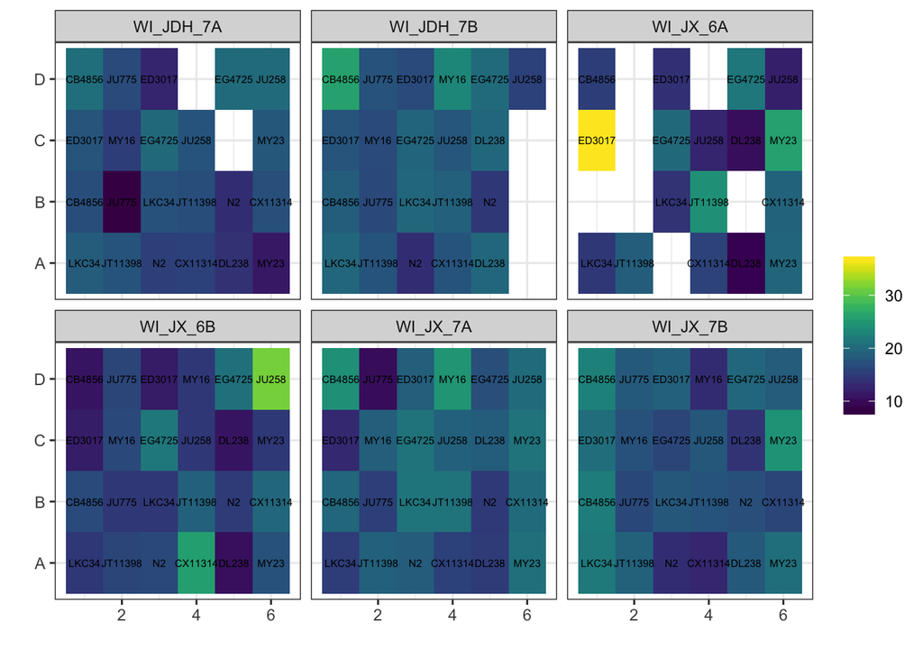

### WormWatcher traits

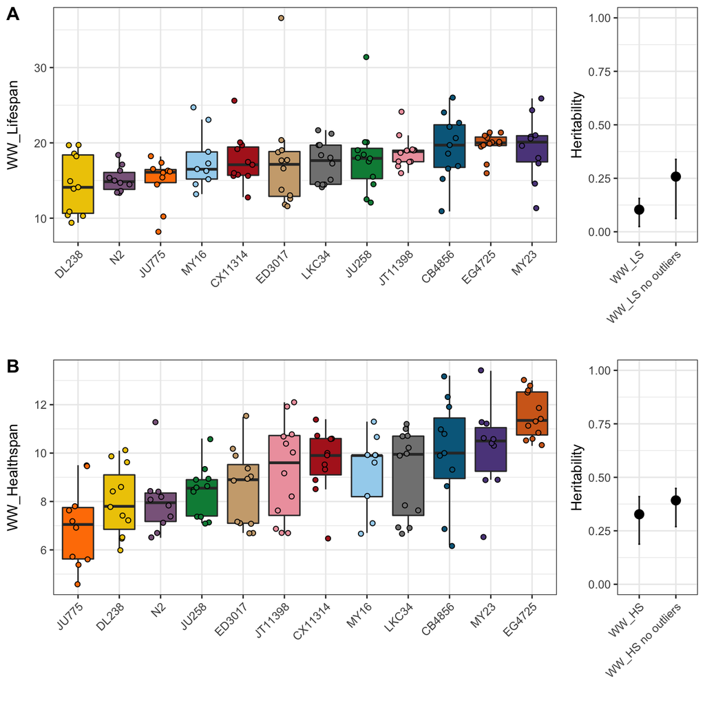

**(A-B)** Box plots for traits measured using WormWatcher (WW). **(A)** broad-sense heritability = 0.103 for Lifespan, but with outliers removed heritability = 0.257. **(B)** broad-sense heritability = 0.327 for Healthspan, with outlier removal 0.392.

### LifeMachine setup

These data are from Patrick Phillips lab. The data include individual worm lifespans for 20 strains assayed across 13 experiments. The plot below shows the randomized layout of the strains for the 13 experiments. The mean lifespans for individual agar plates are plotted according to the color scale on the right.

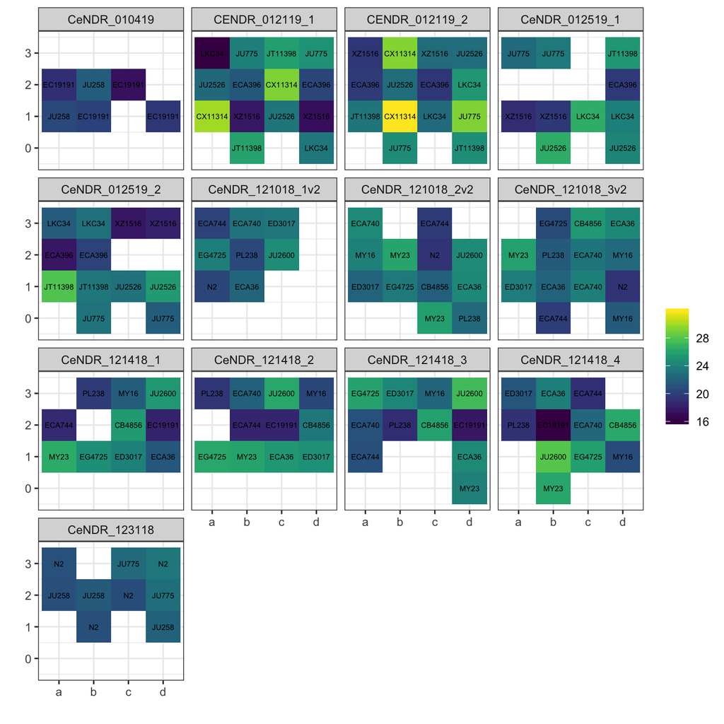

### LifeMachine traits

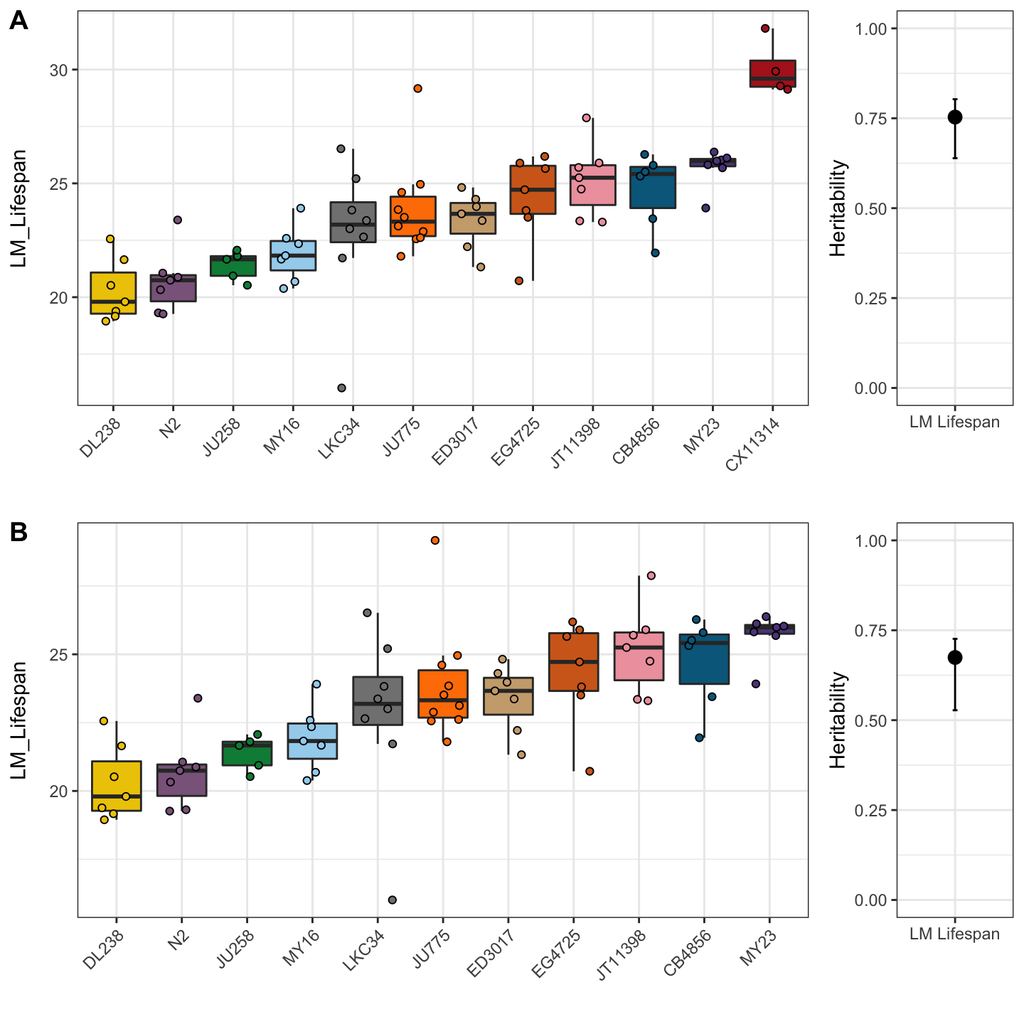

**(A)** Lifespan measured by life machine in Patrick Phillips lab, broad-sense heritability = 0.753. **(B)** The removal of CX11314 lowers broad-sense heritability to 0.674. Data points are mean lifespan for all individuals in plate.

### Platform correlation

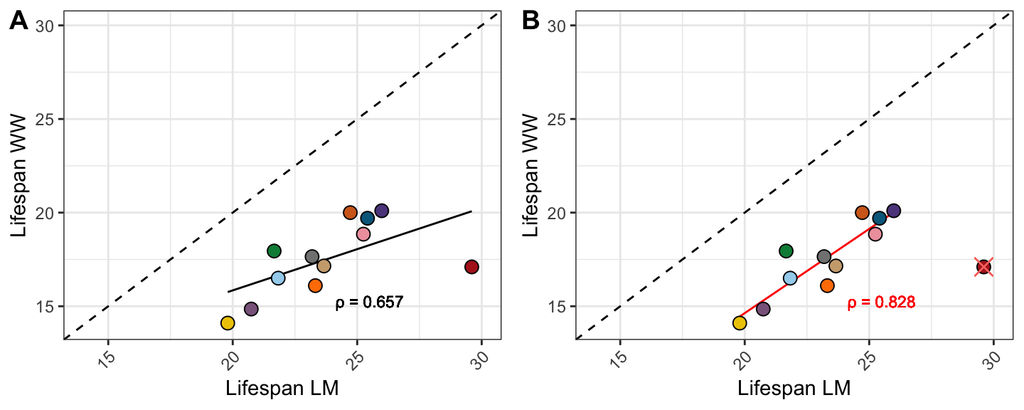

**(A-B)** Correlation of median lifespan estimates between platforms. **(A)** Spearman correlation coefficient with all strains included. **(B)** Same but with CX11314 removed from analysis.

### Heritability calc.

Fit linear mixed-effects model (LMM) to data with Strain as random variable.  
`reffMod <- lme4::lmer(pheno ~ 1 + (1|strain))`  
Extract variance components for strain (Vg), and error (Ve).  
`Variances <- as.data.frame(lme4::VarCorr(reffMod, comp = "Variance"))`  
`Vg <- Variances$vcov[1]`  
`Ve <- Variances$vcov[2]`  
Calculate broad-sense heritability with variance components.  
`H2 <- Vg/(Vg+Ve)`  
Calculate 95% confidence intervals by bootstrap method.